# Simulating Unobservable Spatial Locations with Bayesian Multidimensional Scaling

Robert Kubinec

```r
require(dplyr)
require(tidyr)
require(rstan)
require(bayesplot)
require(abind)
require(trelliscopejs)
```

This code samples $W_{tc}$ wifi locations and $U_{tc}$ user locations from a 2-dimensional plane as a series of coordinates from independent normal distributions $N~(0,10)$ ($t$ for true, $c$ for coordinate, i.e., latitude or longitude). These true locations are unobserved because the data we have from the supermarket only includes noisy measurements, either in terms of wifi signal strength or GPS (longitude/latitude). Accepting either GPS or wifi locations as “true” data will potentially bias estimates by giving the model false precision. Thus I also sample coordinates with measurement error $N~(0,0.25)$ for wifi locations and $N~(0,1)$ for longitude/latitude locations resulting in $W_{oc}$ and $U_{oc}$ ($o$ for observed). Furthermore, the wifi locations $W_{tc}$ are sampled from a series of clusters $C_{sc}$ reflecting the fact that each wifi router belongs to a sub-net, and so we should model the resulting clustering of wifi routers in similar locations.

Finally, distances between the wifi router locations and GPS coordinates of the users are calculated using Euclidean distances $D_oc$. This reflects the nature of the data, which has GPS coordinates at individual time points along with a series of observations of wifi signal strength, which can be converted to distances in feet.

Multidimensional scaling is an appropriate choice for this modeling problem because it finds the points that will minimize the errors of the observed distances between points. Given real distances between spatial locations, such as cities, MDS is able to reconstruct a correct map of the locations based on distances between points. The Bayesian version of MDS is particularly appropriate because it allows us to modify the estimation to take into account the nature of supermarket data as well as to incorporate prior information about the types of beacons and signals we are processing.

In essence, the simulation is as follows:

```r
# model parameters --------------------------------------------------------
niter <- 2000
nwarmup <- 1000
num_points <- 50
test_fix <- 2
err_sd_wifi <- .25
err_sd_gps <- 1
true_sd <- 10
true_points_gps <- matrix(nrow=num_points,c(rnorm(num_points,0,true_sd),rnorm(num_points,0,true_sd)))
true_points_clust <- matrix(nrow=num_points/true_sd,c(rnorm(num_points/true_sd,0,true_sd),rnorm(num_points/true_sd,0,true_sd)))
true_points_wifi <- apply(true_points_clust,2, function(x) {
  x <- sapply(x,function(x) rnorm(n=10,mean=x))
})
obs_points_gps <- apply(true_points_gps,c(1,2),function(x) rnorm(n=1,mean=x,sd=err_sd_gps))
obs_points_wifi <- apply(true_points_wifi,c(1,2), function(x) rnorm(n=1,mean=x,sd=err_sd_wifi))
distance_obs <- proxy::dist(c(rbind(obs_points_wifi,obs_points_gps))) %>% as.matrix()
```

We can show the data by plotting observed and true locations. Below is the simulated data in long form.

```r
plot_data <- bind_cols(as_data_frame(rbind(obs_points_wifi,obs_points_gps)),
                       as_data_frame(rbind(true_points_wifi,true_points_gps)))
names(plot_data) <- c('Observed_Lat','Observed_Lon','True_Lat','True_Lon')
plot_data <- mutate(plot_data,type=rep(c('wifi','gps'),each=num_points),id=1:n(),
                    point_id=rep(1:num_points,2),
                    clust_id=c(paste0('clust_',rep(1:5,each=true_sd)),rep(NA,num_points)))
plot_data <-  gather(plot_data,source,coordinate,-type,-id,-clust_id,-point_id) %>% separate(source,into=c('source','dimension')) %>%
  spread(key = dimension,value = coordinate)
DT::datatable(plot_data)
```

|  | type | id | point_id | clust_id | source | Lat | Lon |
| --- | --- | --- | --- | --- | --- | --- | --- |
| 1 | gps | 51 | 1 |  | Observed | 1.56432831346528 | -3.58741516496365 |
| 2 | gps | 51 | 1 |  | True | 0.61313625512069 | -4.79728830741526 |
| 3 | gps | 52 | 2 |  | Observed | 0.430368943385315 | 2.58349140109158 |
| 4 | gps | 52 | 2 |  | True | -0.981717258657846 | 1.93840981547468 |
| 5 | gps | 53 | 3 |  | Observed | 4.08856233895031 | -11.1613184092834 |
| 6 | gps | 53 | 3 |  | True | 3.11430937654293 | -12.1919390502341 |
| 7 | gps | 54 | 4 |  | Observed | -5.09207820719281 | 3.51242210590248 |
| 8 | gps | 54 | 4 |  | True | -3.5572773060618 | 4.64086130213578 |
| 9 | gps | 55 | 5 |  | Observed | 0.755092136202478 | -3.17678969634376 |
| 10 | gps | 55 | 5 |  | True | 1.44690251272732 | -2.9230630692748 |

[output cut: 190 more lines]

And here is a plot of observed versus true locations for wifi and GPS coordinates.

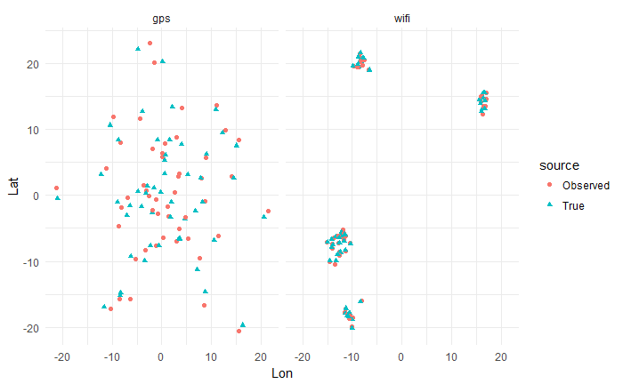

```r
ggplot(plot_data,aes(y=Lat,x=Lon,shape=source,colour=source)) + geom_point() + theme_minimal() +
  facet_wrap(~type)
```

```r
gps_data <- filter(plot_data,source=='Observed',type=='gps') %>% select(point_id,Lat,Lon)
wifi_data <- filter(plot_data,source=='Observed',type=='wifi') %>% select(point_id,clust_id,Lat,Lon)
euclid_dist <- data_frame(distance=c(sapply(gps_data$point_id, function(x) {
  gps_coord <- filter(gps_data,point_id==x)
  distance <- sapply(wifi_data$point_id, function(y) {
    wifi_coord <- filter(wifi_data,point_id==y)
    out_dist <- sqrt((gps_coord$Lat - wifi_coord$Lat)^2 + (gps_coord$Lon - wifi_coord$Lon)^2)
    })
  return(distance)
})),
point_id=rep(gps_data$point_id,each=num_points),wifi_id=rep(wifi_data$point_id,num_points))
simul_data <- left_join(plot_data,euclid_dist,by='point_id') %>% group_by(point_id) %>%
  filter(type=='gps',source=='Observed',distance<10) %>%
  left_join(select(wifi_data,point_id,clust_id),by=c('wifi_id'='point_id'))
DT::datatable(select(simul_data,point_id,wifi_id,clust_id.y,Lat,Lon,distance),rownames=FALSE)
```

| point_id | wifi_id | clust_id.y | Lat | Lon | distance |
| --- | --- | --- | --- | --- | --- |
| 3 | 37 | clust_4 | 4.08856233895031 | -11.1613184092834 | 9.39262929394846 |
| 3 | 40 | clust_4 | 4.08856233895031 | -11.1613184092834 | 9.81675047518896 |
| 11 | 31 | clust_4 | -1.88090602350532 | -8.13572513272161 | 7.14164613218249 |
| 11 | 32 | clust_4 | -1.88090602350532 | -8.13572513272161 | 6.09303215718728 |
| 11 | 33 | clust_4 | -1.88090602350532 | -8.13572513272161 | 8.09062913077779 |
| 11 | 34 | clust_4 | -1.88090602350532 | -8.13572513272161 | 6.06315075832052 |
| 11 | 35 | clust_4 | -1.88090602350532 | -8.13572513272161 | 5.78414400185752 |
| 11 | 36 | clust_4 | -1.88090602350532 | -8.13572513272161 | 5.9949624052706 |
| 11 | 37 | clust_4 | -1.88090602350532 | -8.13572513272161 | 5.08635231401715 |
| 11 | 38 | clust_4 | -1.88090602350532 | -8.13572513272161 | 6.62028719820956 |

[output cut: 209 more lines]

Now that we have generated data from first principles, we can look at how various models perform at guessing true user locations. First we can examine a relatively straightforward hiearchical linear model where longitude/latitude is the outcome and distance to wifi signals are the predictors. In this model I include a random intercept for cluster location and a 3-order polynomial for wifi distance. The model is fit in Stan using the `rstan` package.

```r
# produce model matrix for Stan
theta <- model.matrix(~distance + I(distance^2) + I(distance^3),data = simul_data)[,-1]
stan_data <- list(N=nrow(simul_data),
                  J=ncol(theta),
                  X=theta,
                  longitude=simul_data$Lon,
                  latitude=simul_data$Lat,
                  G=num_points/true_sd,
                  cl=as.numeric(factor(simul_data$clust_id.y)))
compiled <- stan_model(file='hier_linear.stan')
```

[output not shown]